# Lista 1 - Ajustando uma RNA ‘no braço’

Matheus Stivali

28/07/2021

# Introdução

Este trabalho tem o objetivo de implementar passo a passo uma rede neural na linguagem R, sem recorrer a pacotes ou rotinas específicas pré-progamadas para os cálculos e estimativas.

O processo gerador de dados “real”, que os diferentes passos buscam identificar é dado pelo processo:

$$Y \sim N(\mu,\sigma = 1) \\
\mu = |X_{1}^{3} - 30 \times sen(X_{2}) + 10| \\
X_{j} \sim \text{Uniforme(-3,3); j=1,2.}$$
Que é gerado pelo código abaixo e armazenado no objetos `dados`.

```r
### Gerando dados "observados"
set.seed(2.2020)
m.obs <- 100000
dados <- tibble(x1.obs=runif(m.obs, -3, 3),
                x2.obs=runif(m.obs, -3, 3)) %>%
  mutate(mu=abs(x1.obs^3 - 30*sin(x2.obs) + 10),
         y=rnorm(m.obs, mean=mu, sd=1))
```

Busca-se construir uma rede neural com um camada escondida contendo dois neurônios, podendo ser descrita por:

$$\text{Camada escondida:} \\
h_1 = \phi(x_1w_1+x_2w_3 + b_1) = \phi(a_1) \\
h_2 = \phi(x_1w_2+x_2w_4 + b_2) = \phi(a_2) \\
\text{Camada de saída:} \\
\hat{y} = h_1w_5+h_2w_6 + b_3$$
Ou então, matricialmente (os subscritos indicam as dimensões das matrizes):

$$\underbrace{
y_{1,n} =
\begin{bmatrix}
y_{1} \\
y_{2} \\
\ldots
\end{bmatrix}}_{\text{Dados observados}}
;\hspace{5pt}
\underbrace{
X_{2,n} =
\begin{bmatrix}
x_{1,1} & x_{1,2} \\
x_{2,1} & x_{2,2} \\
\ldots & \ldots
\end{bmatrix}}_{\text{Matrix Design}}
;\hspace{5pt}
\underbrace{
\theta_{1,9}^T = (w_1, w_2, w_3, w_4, w_5, w_6, b_1, b_2, b_3)
}_{\text{Vetor de pesos}} \\
\underbrace{
W^{(1)}_{2,2} =
\begin{bmatrix}
w_{1} & w_{2} \\
w_{3} & w_{4}
\end{bmatrix}}_{\text{Pesos da 1ª camada}}
;\hspace{5pt}
\underbrace{
b^{(1)}_{2,1} =
\begin{bmatrix}
b_{1} \\
b_{2}
\end{bmatrix}}_{\text{Vieses da 1ª camada}}
;\hspace{5pt}
\underbrace{
W^{(2)}_{1,2} =
\begin{bmatrix}
w_{5} \\
w_{6}
\end{bmatrix}}_{\text{Pesos da 2ª camada}}
;\hspace{5pt}
\underbrace{
b^{(2)}_{1,1} =
b_{3}}_{\text{Viés da 2ª camada}}
;\hspace{5pt}
\underbrace{
\phi(x) = \dfrac{1}{1+e^{-x}}
}_{\text{Função de ativação}}\\
h_{2,1} = \phi ( XW^{(1)}+ [b^{(1) T}] ) = \phi(a_{2,1}) =
\underbrace{
\begin{bmatrix}
h_{1,1} & h_{1,2} \\
h_{2,1} & h_{2,2} \\
\ldots & \ldots
\end{bmatrix}_{n,2}}_{\text{Resultado da 1ª camada}} \\
\hat{y}_{n,1} = h W^{(2)} + [b_{3}]_{n,1} =
\underbrace{
\begin{bmatrix}
\hat{y}_{1} \\
\hat{y}_{2} \\
\ldots
\end{bmatrix}_{n,1}}_{\text{Saída}} \\$$

Isto é, os dados de input da *matriz design* ($x_{i,1}$ e $x_{i,2}$) são transformados na primeira camada pela aplicação em sequência de uma transormação linear ($W^{(1)}$) e de uma transformação não linear $\phi(.)$. Onde $\phi(.)$ é a função de ativação logística: $\phi(x) = \dfrac{1}{1+e^{-x}}$ Finalmente, os resultados da camada escondida são levados a camada de saída por uma outra transformação linear ($W^{(2)}$). Cada transformação linear é acompanhada da soma dos viéses ($b^{(1)}$ e $b^{(2)}$, respectivamente).

## 1. Função de previsão: $\hat{y} = f(x,\theta)$

O primeiro passo é implementar uma função que forneça uma estimativa $\hat{y}$ em função de x e $\theta$ com as transformações lineares e não lineares descritas acima. E então utilizar essa função para $\hat{y}$ considerados o vetor de pesos $\theta_{1,9}^T = (0.1, 0.1, 0.1, 0.1, 0.1, 0.1, 0.1, 0.1, 0.1)$ e uma matriz design com apenas uma linha $X = [1, 1]$.

Inicia-se definindo os diferentes componentes da rede neural no R:

```r
##########################################################################
###  Componentes da rede
##########################################################################
theta_0 <- rep(0.1,9)
W1 <- matrix(theta_0[1:4], nrow=2, byrow=TRUE)
W2 <- matrix(theta_0[5:6], nrow=2, byrow=TRUE)
b1 <- matrix(theta_0[7:8], nrow=2, byrow=TRUE)
b3 <- theta_0[9]
X <- matrix( c(1,1), ncol=2)
# Phi - função de ativação logística
fih <- function(x) {
  1 / (1 + exp(-x))
  }
```

Antes de se automatizar o processo em uma função pode-se implementar as transformações previstas na rede uma a uma:

```r
##########################################################################
## Passo a passo, sem automatizar na função
##########################################################################
passo1 = X %*% W1
passo2 = passo1 + t(b1)
passo3 = fih(passo2)
passo4 = passo3 %*% W2
saida = passo4 + b3
  saida
```

```
##           [,1]
## [1,] 0.2148885
```

Por fim define-se a função de forma que ela funcione com uma matrix desing sem número de observações pré-definido

```r
##########################################################################
## Definindo os valores:
##########################################################################
X <- t(as.matrix(c(1,1)))
Y <- as.matrix(c(1)) # Aqui apenas auxiliar
theta_0 <- c(0.1, 0.1, 0.1, 0.1, 0.1, 0.1, 0.1, 0.1, 0.1)

##########################################################################
## Agrupando os componentes em uma lista
##########################################################################
componentes1 <- list(entrada = X,
                    observado = Y,
                    pesos_c1 = matrix(theta_0[1:4], nrow = 2, byrow = TRUE),
                    vies_c1 = matrix(theta_0[7:8], ncol = 2, nrow = dim(X)[1], byrow=TRUE),
                    pesos_cs = matrix(theta_0[5:6], nrow = 2, byrow = TRUE),
                    vies_cs = matrix(theta_0[9], ncol = 1, nrow = dim(Y)[1], byrow = TRUE),
                    camada_tl = matrix(rep(0,dim(X)[1]*dim(X)[2]),
                                       nrow=dim(X)[1], ncol=dim(X)[2],
                                       byrow = TRUE),
                    camada_tnl = matrix(rep(0,dim(X)[1]*dim(X)[2]),
                                        nrow=dim(X)[1], ncol=dim(X)[2],
                                        byrow = TRUE),
                    saida = matrix(rep(0,dim(Y)[1]), ncol=1)
                    )

##########################################################################
## Função de previsão
##########################################################################
previsao <- function(rn) {
  rn$camada_tl <- (rn$entrada %*% rn$pesos_c1) + rn$vies_c1
  rn$camada_tnl <- fih(rn$camada_tl)
  rn$saida <- (rn$camada_tnl %*% rn$pesos_cs) + rn$vies_cs
  return(rn)
  }

previsao(componentes1)$saida
```

```
##           [,1]
## [1,] 0.2148885
```

## 2. Função de custo

A função custo que se vai adotar para a rede é:

$$J(\theta) = \dfrac{1}{m} \sum^{m}_{i=1}L(f(x_{1,i},x_{2,i}),y_i) =
\dfrac{\sum^{m}_{i=1}(y_i - \hat{y}_i)^2}{m}$$

```r
##########################################################################
## Função de custo
##########################################################################
custo <- function(rn){
  mean((rn$observado - rn$saida)^2)
}
```

Considerando o **conjunto de treinamento** (as primeiras 80000 observações dos dados) o custo da rede é de `670.3107`.

```r
##########################################################################
## Divisão do conjunto de dados
##########################################################################
X_trein <- as.matrix(dados[1:80000,1:2])
X_teste <- as.matrix(dados[80001:100000,1:2])
Y_trein <- as.matrix(dados[1:80000,4])
Y_teste <- as.matrix(dados[80001:100000,4])

##########################################################################
## Cálculo do custo
##########################################################################
theta_0 <- c(0.1, 0.1, 0.1, 0.1, 0.1, 0.1, 0.1, 0.1, 0.1)
componentes2 <- list(entrada = X_trein,
                    observado = Y_trein,
                    pesos_c1 = matrix(theta_0[1:4], nrow = 2, byrow = TRUE),
                    vies_c1 = matrix(theta_0[7:8], ncol = 2, nrow = dim(X_trein)[1], byrow=TRUE),
                    pesos_cs = matrix(theta_0[5:6], nrow = 2, byrow = TRUE),
                    vies_cs = matrix(theta_0[9], ncol = 1, nrow = dim(Y_trein)[1], byrow = TRUE),
                    camada_tl = matrix(rep(0,dim(X_trein)[1]*dim(X_trein)[2]),
                                       nrow=dim(X_trein)[1], ncol=dim(X_trein)[2],
                                       byrow = TRUE),
                    camada_tnl = matrix(rep(0,dim(X_trein)[1]*dim(X_trein)[2]),
                                        nrow=dim(X_trein)[1], ncol=dim(X_trein)[2],
                                        byrow = TRUE),
                    saida = matrix(rep(0,dim(Y_trein)[1]), ncol=1)
                    )

conj_trein_hat <- previsao(componentes2)
custo(conj_trein_hat)
```

```
## [1] 670.3107
```

Considerando o **conjunto de teste** (as últimas 20000 observações dos dados) o custo da rede é de `665.0861`.

```r
##########################################################################
## Cálculo do custo
##########################################################################
theta_0 <- c(0.1, 0.1, 0.1, 0.1, 0.1, 0.1, 0.1, 0.1, 0.1)
componentes3 <- list(entrada = X_teste,
                    observado = Y_teste,
                    pesos_c1 = matrix(theta_0[1:4], nrow = 2, byrow = TRUE),
                    vies_c1 = matrix(theta_0[7:8], ncol = 2, nrow = dim(X_teste)[1], byrow=TRUE),
                    pesos_cs = matrix(theta_0[5:6], nrow = 2, byrow = TRUE),
                    vies_cs = matrix(theta_0[9], ncol = 1, nrow = dim(X_teste)[1], byrow = TRUE),
                    camada_tl = matrix(rep(0,dim(X_teste)[1]*dim(X_teste)[2]),
                                       nrow=dim(X_teste)[1], ncol=dim(X_teste)[2],
                                       byrow = TRUE),
                    camada_tnl = matrix(rep(0,dim(X_teste)[1]*dim(X_teste)[2]),
                                        nrow=dim(X_teste)[1], ncol=dim(X_teste)[2],
                                        byrow = TRUE),
                    saida = matrix(rep(0,dim(Y_teste)[1]), ncol=1)
                    )

conj_test_hat <- previsao(componentes3)
custo(conj_test_hat)
```

```
## [1] 665.0861
```

## 3. Vetor gradiente da função de custo

Nesse passo vamos obter as expressões algébricas do vetor gradiente $\nabla_\theta(J)$ da função custo em relação aos parâmetros contidos em $\theta$.

### 3.1. Derivada da função de custo

$$J(\theta) = \dfrac{1}{m} \sum^{m}_{i=1}L(f(x_{1,i},x_{2,i}),y_i) =
\dfrac{\sum^{m}_{i=1}(y_i - \hat{y}_i)^2}{m} \\
\dfrac{\partial J(\theta)}{\partial \theta_j} =
\dfrac{1}{m} \times 2 \times \sum^{m}_{i=1} (y_i - \hat{y}_i) \times
\bigg( -\dfrac{\partial \hat{y}}{\partial \theta_j} \bigg)$$

### 3.2. Derivadas da função de previsão

$$f(x_{i,1},x_{i,2};\theta) = \hat{y}_i=
\phi(x_{i,1}w_{1}+x_{i,2}w_{3}+b_{1}) \times w_{5}
+
\phi(x_{i,1}w_{2}+x_{i,2}w_{4}+b_{2}) \times w_{6}
+ b_{3}\\
1) \dfrac{\partial \hat{y}}{\partial w_{1}} =
x_{i,1} w_{5} \times \phi'(x_{i,1}w_{1}+x_{i,2}w_{3}+b_{1}) \\
2) \dfrac{\partial \hat{y}}{\partial w_{3}} =
x_{i,2} w_{5} \times \phi'(x_{i,1}w_{1}+x_{i,2}w_{3}+b_{1}) \\
3) \dfrac{\partial \hat{y}}{\partial w_{2}} =
x_{i,1} w_{6} \times \phi'(x_{i,1}w_{2}+x_{i,2}w_{4}+b_{2}) \\
4) \dfrac{\partial \hat{y}}{\partial w_{4}} =
x_{i,2} w_{6} \times \phi'(x_{i,1}w_{2}+x_{i,2}w_{4}+b_{2}) \\
5) \dfrac{\partial \hat{y}}{\partial w_{5}} =
\phi(x_{i,1}w_{1}+x_{i,2}w_{3}+b_{1}) \\
6) \dfrac{\partial \hat{y}}{\partial w_{6}} =
\phi(x_{i,1}w_{2}+x_{i,2}w_{4}+b_{2}) \\
7) \dfrac{\partial \hat{y}}{\partial b_{1}} =
w_{5} \times \phi'(x_{i,1}w_{1}+x_{i,2}w_{3}+b_{1}) \\
8) \dfrac{\partial \hat{y}}{\partial b_{2}} =
w_{6} \times \phi'(x_{i,1}w_{2}+x_{i,2}w_{4}+b_{2}) \\
9) \dfrac{\partial \hat{y}}{\partial b_{3}} = 1$$

### 3.3. Derivada da função de ativação

$$\phi(x) = \dfrac{1}{1+e^{-x}} \\
\frac{d\phi(x)}{dx} = -1
(1+e^{-x})^{-2}(0-e^{-x})=\dfrac{e^{-x}}{(1+e^{-x})^2}=\dfrac{1}{1+e^{-x}}
\times \dfrac{e^{-x}}{1+e^{-x}} \\
\frac{d\phi(x)}{dx} = \dfrac{1}{1+e^{-x}} \times
\dfrac{e^{-x}}{1+e^{-x}} = \phi(x) \times (1-\phi(x))$$

No R essa derivada pode ser definida como uma função:

```r
#############################################
# Phi_linha - derivada da função logística
#############################################
fih_linha <- function(x) {
 ( 1 / (1 + exp(-x)) ) * ( 1 - (1 / (1 + exp(-x))) )
 }
```

### 3.4. Vetor gradiente

Nessa subseção os elementos das três últimas subseções são reunidos para compor o vetor gradiente:

$$\nabla_{\theta}J(\theta) =
\begin{pmatrix}
\dfrac{\partial J(\theta)}{\partial w_1}\\
\dfrac{\partial J(\theta)}{\partial w_2}\\
\dfrac{\partial J(\theta)}{\partial w_3}\\
\dfrac{\partial J(\theta)}{\partial w_4}\\
\dfrac{\partial J(\theta)}{\partial w_5}\\
\dfrac{\partial J(\theta)}{\partial w_6}\\
\dfrac{\partial J(\theta)}{\partial b_1}\\
\dfrac{\partial J(\theta)}{\partial b_2}\\
\dfrac{\partial J(\theta)}{\partial b_3}
\end{pmatrix}
=
\begin{pmatrix}
\dfrac{2}{m} \times \sum^{m}_{i=1}(y_i - \hat{y}_i) \times \bigg( -
x_{1} w_{5} \times
\phi'(x_{i,1}w_{1}+x_{i,2}w_{3}+b_{1}) \bigg) \\
\dfrac{2}{m} \times \sum^{m}_{i=1}(y_i - \hat{y}_i) \times \bigg( -
x_{1} w_{6} \times
\phi'(x_{i,1}w_{2}+x_{i,2}w_{4}+b_{2}) \bigg) \\
\dfrac{2}{m} \times \sum^{m}_{i=1}(y_i - \hat{y}_i) \times \bigg( -
x_{2} w_{5} \times
\phi'(x_{i,1}w_{1}+x_{i,2}w_{3}+b_{1}) \bigg) \\
\dfrac{2}{m} \times \sum^{m}_{i=1}(y_i - \hat{y}_i) \times \bigg( -
x_{2} w_{6} \times
\phi'(x_{i,1}w_{2}+x_{i,2}w_{4}+b_{2}) \bigg) \\
\dfrac{2}{m} \times \sum^{m}_{i=1}(y_i - \hat{y}_i) \times \bigg( -
\phi(x_{i,1}w_{1}+x_{i,2}w_{3}+b_{1})
\bigg) \\
\dfrac{2}{m} \times \sum^{m}_{i=1}(y_i - \hat{y}_i) \times \bigg( -
\phi(x_{i,1}w_{2}+x_{i,2}w_{4}+b_{2})
\bigg) \\
\dfrac{2}{m} \times \sum^{m}_{i=1}(y_i - \hat{y}_i) \times \bigg( -
w_{5} \times
\phi'(x_{i,1}w_{1}+x_{i,2}w_{3}+b_{1}) \bigg) \\
\dfrac{2}{m} \times \sum^{m}_{i=1}(y_i - \hat{y}_i) \times \bigg( -
w_{6} \times
\phi'(x_{i,1}w_{2}+x_{i,2}w_{4}+b_{2}) \bigg) \\
\dfrac{2}{m} \times \sum^{m}_{i=1}(y_i - \hat{y}_i) \times (-1) \\
\end{pmatrix}$$

## 4. Computação do vetor gradiente - Backpropagation

Nesse passo é desenvolvida uma função que toma como argumentos a matriz design (X), a matriz dos rótulos (Y), e o vetor de parâmetros ($\theta$)e fornece como saída o vetor gradiente.

```r
#############################################
# Função gradiente com backpropagation
#############################################
gradiente <- function(rn){
  gradi <- rep(0,9)
  ### Elementos que se repetem nas derivadas - calcular só 1 vez
  w5fih_linha <- rn$pesos_cs[1] * fih_linha(rn$camada_tl[,1])
  w6fih_linha <- rn$pesos_cs[2] * fih_linha(rn$camada_tl[,2])
  ###
  gradi[1] <- (2 / dim(rn$observado)[1]) *
                sum( (rn$observado - rn$saida) * (-1) *
                rn$entrada[,1] * w5fih_linha)
  gradi[2] <- (2 / dim(rn$observado)[1]) *
                sum( (rn$observado - rn$saida) * (-1) *
                rn$entrada[,1] * w6fih_linha)
  gradi[3] <- (2 / dim(rn$observado)[1]) *
                sum( (rn$observado - rn$saida) * (-1) *
                rn$entrada[,2] * w5fih_linha)
  gradi[4] <- (2 / dim(rn$observado)[1]) *
                sum( (rn$observado - rn$saida) * (-1) *
                rn$entrada[,2] * w6fih_linha)
  gradi[5] <- (2 / dim(rn$observado)[1]) *
                sum( (rn$observado - rn$saida) * (-1) *
                fih(rn$camada_tl[,1]))
  gradi[6] <- (2 / dim(rn$observado)[1]) *
                sum( (rn$observado - rn$saida) * (-1) *
                fih(rn$camada_tl[,2]))
  gradi[7] <- (2 / dim(rn$observado)[1]) *
                sum( (rn$observado - rn$saida) * (-1) * w5fih_linha)
  gradi[8] <- (2 / dim(rn$observado)[1]) *
                sum( (rn$observado - rn$saida) * (-1) * w6fih_linha)
  gradi[9] <- (2 / dim(rn$observado)[1]) *
                sum( (rn$observado - rn$saida) * (-1))
  return(gradi)
}
```

Agora essa função é aplicada ao conjunto de treinamento (as primeiras 80000 observações dos dados) com o vetor de parâmetros $\theta_{1,9}^T = (0.1, 0.1, 0.1, 0.1, 0.1, 0.1, 0.1, 0.1, 0.1)$.

```r
#############################################
# Argumentos da função
#############################################
theta_0 <- c(0.1, 0.1, 0.1, 0.1, 0.1, 0.1, 0.1, 0.1, 0.1)
componentes4 <- list(entrada = X_trein,
                    observado = Y_trein,
                    pesos_c1 = matrix(theta_0[1:4], nrow = 2, byrow = TRUE),
                    vies_c1 = matrix(theta_0[7:8], ncol = 2, nrow = dim(X_trein)[1], byrow=TRUE),
                    pesos_cs = matrix(theta_0[5:6], nrow = 2, byrow = TRUE),
                    vies_cs = matrix(theta_0[9], ncol = 1, nrow = dim(Y_trein)[1], byrow = TRUE),
                    camada_tl = matrix(rep(0,dim(X_trein)[1]*dim(X_trein)[2]),
                                       nrow=dim(X_trein)[1], ncol=dim(X_trein)[2],
                                       byrow = TRUE),
                    camada_tnl = matrix(rep(0,dim(X_trein)[1]*dim(X_trein)[2]),
                                        nrow=dim(X_trein)[1], ncol=dim(X_trein)[2],
                                        byrow = TRUE),
                    saida = matrix(rep(0,dim(Y_trein)[1]), ncol=1)
                    )

# Gerando a previsão
componentes4 <- previsao(componentes4)

gradiente(componentes4)
```

```
## [1]  -0.1700960  -0.1700960   0.6357381   0.6357381 -22.3590539 -22.3590539
## [7]  -1.0746279  -1.0746279 -43.4700502
```

## 5. Minimização da função custo pelo método do gradiente

Considerando a rede,a função custo e a função gradiente definidas anteriormente, nesta seção serão procurados os parâmetros ($\theta$) que minimizam a função custo. A minimização da função custo será realizada pelo método do gradiente. O gradiente de uma função representa o vetor que indica a direção para qual aquela superfície cresce naquele ponto. Dada a função custo adotada, a busca pelo mínimo tem que ocorrer na direção oposta do gradiente.

Assim, o procedimento nessa seção será:

1. Inicializar a rede com parâmetros pré-definidos
1. Definir a lista `componentes` e usar a função `previsao`
2. Calcular o `custo` da rede com aqueles parâmetros e armazenar
3. Calcular o gradiente da função custo (`gradiente`) e atualizar os parâmetros utilizando a taxa de aprendizagem $\epsilon$=`0.1`.

$$\theta_{novo} = \theta_{antigo} - \nabla_{\theta}J(\theta_{antigo})
\times \epsilon$$
4. Substituir os novos valores na lista `componentes`.

### 5.1 Minimização no conjunto de treinamento

```r
#######################################################
## Parâmetros de inicialização
#######################################################
n <- 100 # Número de iterações
tx_aprendisagem <- 0.1

theta_0 <- c(0, 0, 0, 0, 0, 0, 0, 0, 0)
componentes_aj <- list(entrada = X_trein,
                    observado = Y_trein,
                    pesos_c1 = matrix(theta_0[1:4], nrow = 2, byrow = TRUE),
                    vies_c1 = matrix(theta_0[7:8], ncol = 2, nrow = dim(X_trein)[1], byrow=TRUE),
                    pesos_cs = matrix(theta_0[5:6], nrow = 2, byrow = TRUE),
                    vies_cs = matrix(theta_0[9], ncol = 1, nrow = dim(Y_trein)[1], byrow = TRUE),
                    camada_tl = matrix(rep(0,dim(X_trein)[1]*dim(X_trein)[2]),
                                       nrow=dim(X_trein)[1], ncol=dim(X_trein)[2],
                                       byrow = TRUE),
                    camada_tnl = matrix(rep(0,dim(X_trein)[1]*dim(X_trein)[2]),
                                        nrow=dim(X_trein)[1], ncol=dim(X_trein)[2],
                                        byrow = TRUE),
                    saida = matrix(rep(0,dim(Y_trein)[1]), ncol=1)
                    )


##############################################
## Log do custo ao longo das iterações
##############################################
custo_evol <- data.frame(
  iteracao = 1:n,
  cost = rep(0,n)
)

# Armazena os parâmetros de cada iteração
thetas <- data.frame()

#######################################################
## Minimização do erro
#######################################################
for (i in seq_len(n)){
  # Estimativa
  componentes_aj <- previsao(componentes_aj)
  # Cálculo do custo
  custo_evol$cost[i] <- custo(componentes_aj)
  # Atualização dos parâmetros
  thetas <- rbind(thetas, theta_0)
  theta_0 <- theta_0 - (tx_aprendisagem * gradiente(componentes_aj))
  componentes_aj$pesos_c1 <- matrix(theta_0[1:4], nrow = 2, byrow = TRUE)
  componentes_aj$vies_c1 <- matrix(theta_0[7:8], ncol = 2, nrow = dim(X_trein)[1], byrow=TRUE)
  componentes_aj$pesos_cs <- matrix(theta_0[5:6], nrow = 2, byrow = TRUE)
  componentes_aj$vies_cs <- matrix(theta_0[9], ncol = 1, nrow = dim(Y_trein)[1], byrow = TRUE)
  }
```

O custo mínimo foi obtido na iteração 19:

```r
custo_evol[which.min(custo_evol$cost),]
```

```
##    iteracao     cost
## 19       19 145.0926
```

O vetor de parâmetros obtidos na iteração 19 é:

```r
thetas[19,]
```

```
##           X0      X0.1      X0.2      X0.3     X0.4     X0.5     X0.6     X0.7
## 19 -1.192403 -1.192403 -2.294933 -2.294933 8.272572 8.272572 2.179519 2.179519
##        X0.8
## 19 11.35895
```

### 5.2 Minimização no conjunto de teste

```r
#######################################################
## Parâmetros de inicialização
#######################################################
n <- 100 # Número de iterações
tx_aprendisagem <- 0.1

theta_0 <- c(0, 0, 0, 0, 0, 0, 0, 0, 0)
componentest_aj <- list(entrada = X_teste,
                    observado = Y_teste,
                    pesos_c1 = matrix(theta_0[1:4], nrow = 2, byrow = TRUE),
                    vies_c1 = matrix(theta_0[7:8], ncol = 2, nrow = dim(X_teste)[1], byrow=TRUE),
                    pesos_cs = matrix(theta_0[5:6], nrow = 2, byrow = TRUE),
                    vies_cs = matrix(theta_0[9], ncol = 1, nrow = dim(X_teste)[1], byrow = TRUE),
                    camada_tl = matrix(rep(0,dim(X_teste)[1]*dim(X_teste)[2]),
                                       nrow=dim(X_teste)[1], ncol=dim(X_teste)[2],
                                       byrow = TRUE),
                    camada_tnl = matrix(rep(0,dim(X_teste)[1]*dim(X_teste)[2]),
                                        nrow=dim(X_teste)[1], ncol=dim(X_teste)[2],
                                        byrow = TRUE),
                    saida = matrix(rep(0,dim(Y_teste)[1]), ncol=1)
                    )


##############################################
## Log do custo ao longo das iterações
##############################################
custo_evolt <- data.frame(
  iteracao = 1:n,
  cost = rep(0,n)
)

# Armazena os parâmetros de cada iteração
thetast <- data.frame()

#######################################################
## Minimização do erro
#######################################################
for (i in seq_len(n)){
  # Estimativa
  componentest_aj <- previsao(componentest_aj)
  # Cálculo do custo
  custo_evolt$cost[i] <- custo(componentest_aj)
  # Atualização dos parâmetros
  thetast <- rbind(thetast, theta_0)
  theta_0 <- theta_0 - (tx_aprendisagem * gradiente(componentest_aj))
  componentest_aj$pesos_c1 <- matrix(theta_0[1:4], nrow = 2, byrow = TRUE)
  componentest_aj$vies_c1 <- matrix(theta_0[7:8], ncol = 2, nrow = dim(X_teste)[1], byrow=TRUE)
  componentest_aj$pesos_cs <- matrix(theta_0[5:6], nrow = 2, byrow = TRUE)
  componentest_aj$vies_cs <- matrix(theta_0[9], ncol = 1, nrow = dim(Y_teste)[1], byrow = TRUE)
  }
```

O custo mínimo foi obtido na iteração 19:

```r
custo_evolt[which.min(custo_evolt$cost),]
```

```
##    iteracao     cost
## 19       19 144.2809
```

O vetor de parâmetros final é

```r
thetast[19,]
```

```
##           X0      X0.1      X0.2      X0.3     X0.4     X0.5     X0.6     X0.7
## 19 -1.162785 -1.162785 -2.267624 -2.267624 8.245969 8.245969 2.132469 2.132469
##        X0.8
## 19 11.33173
```

## 6. Otimização no conjunto de treinamento e de teste

Nesse passo são comparadas as minimizações da função custo no conjunto de treinamento e no conjunto de teste.

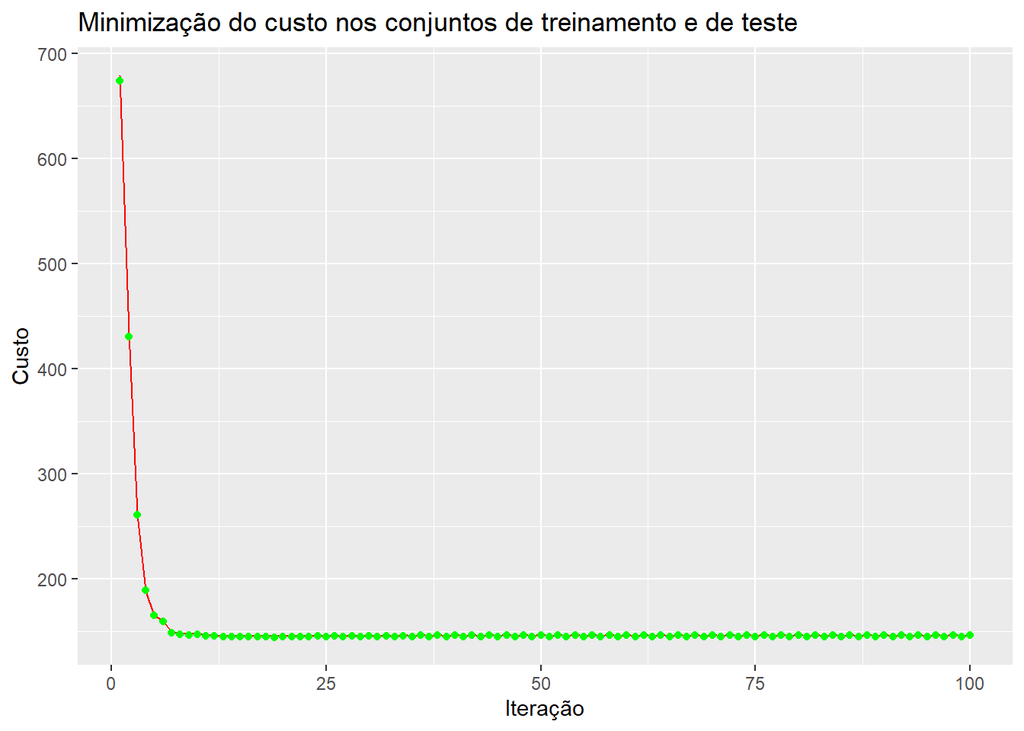

```r
ggplot(data = custo_evol, aes(x = iteracao, y = cost)) +
  geom_line(colour="red") +
  geom_point(data = custo_evolt, colour="green") +
  ggtitle("Minimização do custo nos conjuntos de treinamento e de teste") +
  xlab("Iteração") + ylab("Custo")
```

No gráfico acima a minimização do custo no conjunto de treinamento é mostrada na linha contínua em vermelho e no conjunto de teste nos pontos verdes. Em ambos o caso a minimização é bastente similar o que é natural dado que os dados tem o mesmo processo gerador. Após uma grande redução no custo após as cinco primeira iterações, as iterações seguintes fazem o custo variar entre valores muito próximos.

## 7. Gráfico de resíduos contra features

Nessa etapa será construída uma representação gráfica dos resíduos obtidos na última iteração do conjunto de treinamento contras as features da rede neural.

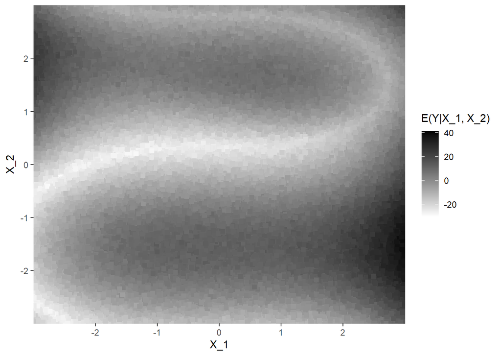

```r
dados.grid <- as_tibble(componentes_aj$entrada) %>%
    rename_all(~ c("x1", "x2")) %>%
    mutate(res=componentes_aj$observado - componentes_aj$saida)


ggplot(dados.grid, aes(x=x1, y=x2)) +
  geom_point(aes(colour=dados.grid$res), size=2, shape=15) +
  coord_cartesian(expand=F) +
  scale_colour_gradient(low="white",
  high="black",
  name=TeX("E(Y|X_1, X_2)")) +
  xlab(TeX("X_1")) + ylab(TeX("X_2"))
```

Pelo gráfico pode-se notar que o modelo da rede neural **erra mais**, isto é, gera resíduos maiores em algumas regiões específicas. Notadamente ao redor dos pontos $(x_1,x_2) = (-3,3/2)$ e $(x_1,x_2) = (3,-3/2)$.

## 8. Gráfico do valor previsto x valor observado (Treinamento e Teste)

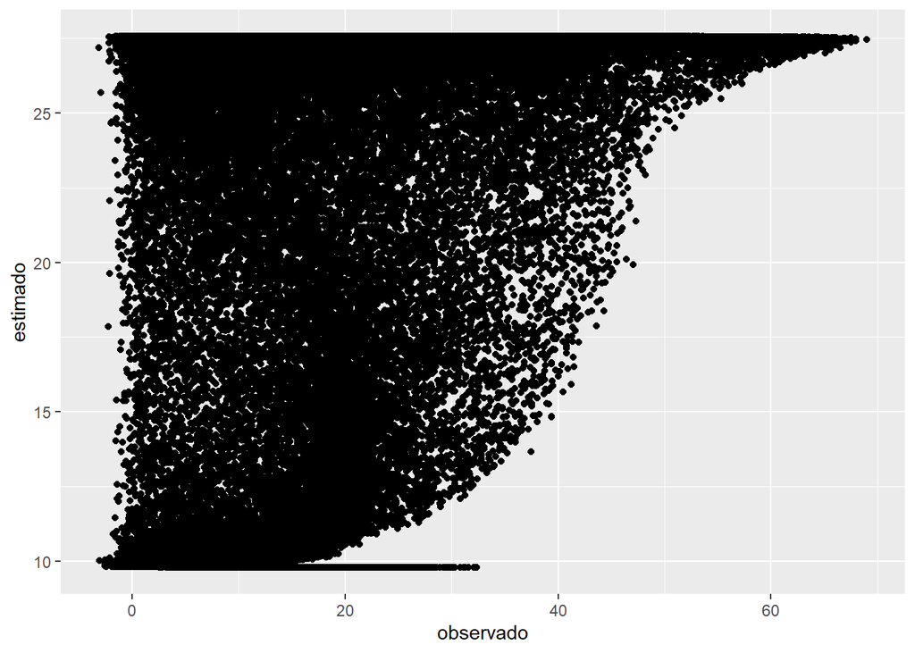

```r
grafico <- as_tibble(componentes_aj$observado) %>%
                rename_all(~ c("observado")) %>%
                mutate(estimado = componentes_aj$saida)

ggplot(data = grafico, aes(x=observado, y=estimado)) +
  geom_point()
```

## 9. Evolução do valor do gradiente k=1 a k=300

```r
#######################################################
## Parâmetros de inicialização
#######################################################
n <- 300 # Tamanho máximo

##############################################
## Log do primeiro elemento do gradiente
##############################################
grad_evol <- data.frame(
  iteracao = 1:n,
  dJ_dw1 = rep(0,n)
)

for (i in seq_len(n)){
  X <- as.matrix(dados[1:i,1:2])
  Y <- as.matrix(dados[1:i,4])
  theta_0 <- c(0.1, 0.1, 0.1, 0.1, 0.1, 0.1, 0.1, 0.1, 0.1)
  componentes5 <- list(entrada = X,
                    observado = Y,
                    pesos_c1 = matrix(theta_0[1:4], nrow = 2, byrow = TRUE),
                    vies_c1 = matrix(theta_0[7:8], ncol = 2, nrow = dim(X)[1], byrow=TRUE),
                    pesos_cs = matrix(theta_0[5:6], nrow = 2, byrow = TRUE),
                    vies_cs = matrix(theta_0[9], ncol = 1, nrow = dim(Y)[1], byrow = TRUE),
                    camada_tl = matrix(rep(0,dim(X)[1]*dim(X)[2]),
                                       nrow=dim(X)[1], ncol=dim(X)[2],
                                       byrow = TRUE),
                    camada_tnl = matrix(rep(0,dim(X)[1]*dim(X)[2]),
                                        nrow=dim(X)[1], ncol=dim(X)[2],
                                        byrow = TRUE),
                    saida = matrix(rep(0,dim(Y)[1]), ncol=1)
                    )
  grad_evol$dJ_dw1[i] <- gradiente(componentes5)[1]
  }
```

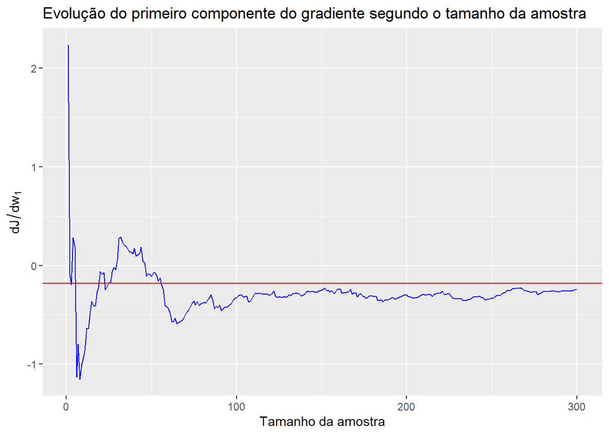

```r
ggplot(data = grad_evol, aes(x = iteracao, y = dJ_dw1)) +
  geom_line(colour="blue") +
  geom_hline(yintercept=-0.1802081, color="red") +
  ggtitle("Evolução do primeiro componente do gradiente segundo o tamanho da amostra") +
  xlab("Tamanho da amostra") + ylab(TeX("$dJ/dw_1$"))
```

```r
library(microbenchmark)
teste <- function(k){
  X <- as.matrix(dados[1:k,1:2])
  Y <- as.matrix(dados[1:k,4])
  theta_0 <- c(0.1, 0.1, 0.1, 0.1, 0.1, 0.1, 0.1, 0.1, 0.1)
  componentes6 <- list(entrada = X,
                    observado = Y,
                    pesos_c1 = matrix(theta_0[1:4], nrow = 2, byrow = TRUE),
                    vies_c1 = matrix(theta_0[7:8], ncol = 2, nrow = dim(X)[1], byrow=TRUE),
                    pesos_cs = matrix(theta_0[5:6], nrow = 2, byrow = TRUE),
                    vies_cs = matrix(theta_0[9], ncol = 1, nrow = dim(Y)[1], byrow = TRUE),
                    camada_tl = matrix(rep(0,dim(X)[1]*dim(X)[2]),
                                       nrow=dim(X)[1], ncol=dim(X)[2],
                                       byrow = TRUE),
                    camada_tnl = matrix(rep(0,dim(X)[1]*dim(X)[2]),
                                        nrow=dim(X)[1], ncol=dim(X)[2],
                                        byrow = TRUE),
                    saida = matrix(rep(0,dim(Y)[1]), ncol=1)
                    )
  gradiente(componentes6)
}

rbind(microbenchmark(teste(300)), microbenchmark(teste(100000)))
```

```
## Unit: microseconds
##          expr     min      lq      mean   median       uq     max neval
##    teste(300)   250.9   257.9   400.822   289.70   330.45 10472.6   100
##  teste(1e+05) 12203.4 16112.3 23643.639 18795.85 21862.60 84254.8   100
```

## 10. Modelo linear sobre o conjunto de treinamento

Nessa etapa são ajustados dois modelos lineares sobre o conjunto de treinamento para fins de comparação com o resultado obtido com o ajuste da rede neural. O primeiro é um modelo simples apenas com $x_1$ e $x_2$ como variáveis explicativas e o segundo inclui essas variáveis ao quadrado e também um termo de interação entre elas.

$$Y_i \sim N(\beta_0 + \beta_1 x_{1,i} + \beta_2 x_{2,i}, \sigma) \\
E(Y_i|x_1,x_2) = \beta_0 + \beta_1 x_{1} + \beta_2 x_{2} + \epsilon
\Rightarrow \text{Modelo linear 1}\\
E(Y_i|x_1,x_2) = \beta_0 + \beta_1 x_{1} + \beta_2 x_{2} + \beta_3
x_{1}^2 + \beta_4 x_{2}^2 +\beta_5 x_{1} x_{2} + +\epsilon \Rightarrow
\text{Modelo linear 2}$$

```r
  REG <- cbind(dados[1:80000,4], dados[1:80000,1:2])
  ML1 <- lm(y ~ x1.obs + x2.obs, data=REG)
  ML2 <- lm(y ~ x1.obs * x2.obs + I(x1.obs^2) + I(x2.obs^2), data=REG)

  mean(ML1$residuals^2)
```

```
## [1] 139.2203
```

```r
  mean(ML2$residuals^2)
```

```
## [1] 94.70472
```

```r
  # Recuperando o objeto 'componentes' do passo 5 para o conjunto de treinamento
  mean((componentes_aj$observado - componentes_aj$saida)^2)
```

```
## [1] 146.5325
```

## 11. Efeito marginal de x1 no valor esperado em cada modelo.

Nesta etapa são avaliados como uma variação marginal na variável explicativa $x_1$ impacta sobre o valor esperado nos diferentes modelos.

$$\textbf{Efeito marginal na rede neural} \\
f(x_{i,1},x_{i,2};\theta) = \hat{y}_i=
\phi(x_{i,1}w_{1}+x_{i,2}w_{3}+b_{1}) \times w_{5}
+
\phi(x_{i,1}w_{2}+x_{i,2}w_{4}+b_{2}) \times w_{6}
+ b_{3}\\
\dfrac{\partial f}{\partial x_1} =
w_1 \times \phi'(x_{i,1}w_{1}+x_{i,2}w_{3}+b_{1}) \times w_{5} +
w_2 \times \phi'(x_{i,1}w_{2}+x_{i,2}w_{4}+b_{2}) \times w_{6} \\
\dfrac{\partial f}{\partial x_1} =
\boxed{
w_1w_{5} \times \phi'(x_{i,1}w_{1}+x_{i,2}w_{3}+b_{1}) + w_2w6
\times \phi'(x_{i,1}w_{2}+x_{i,2}w_{4}+b_{2})
} \\
\textbf{Efeito marginal na Modelo Linear 1} \\
\hat{y} = \beta_0 + \beta_1 x_{1} + \beta_2 x_{2} + \epsilon\\
\dfrac{\partial \hat{y}}{\partial x_1} = \boxed{\beta_1}\\
\textbf{Efeito marginal na Modelo Linear 2} \\
\hat{y} = \beta_0 + \beta_1 x_{1} + \beta_2 x_{2} + \beta_3 x_{1}^2 +
\beta_4 x_{2}^2 +\beta_5 x_{1} x_{2} + \epsilon \\
\dfrac{\partial \hat{y}}{\partial x_1} = \boxed{\beta_1 + 2\beta_3x_1 +
\beta_5x_2}\\$$

No caso de um incremento marginal de $x_1$ na **rede neural** temos que ele impacta o resultado por dois caminhos, isto é, pelos dois neurônios da camada escondida. Adicionalmente, esse impacto é não linear e depende do ponto em que esse incremento ocorre (isto é, do valor em que a derivada é avaliada). No caso do **modelo linear 1** o efeito é direto e linear, com o incremento de uma unidade de $x_1$ impactando $\beta_1$ no resultado esperado. No caso do **modelo linear 2** tem-se o efeito direto ($\beta_1$), mas também efeitos não-lineares que dependem do ponto de avaliação da derivada devido ao termo quadrático ($2\beta_3x_1$) e ao termo de interação ($\beta_5x_2$).

## 12. Intervalo de confiança de 95%.

Nessa seção vai-se avalia quantas vezes o intervalo de confinaça de 95% continha o valor observado (y) nos três modelos. A princípio espera-se que isso ocorra ao menos 95% das vezes.

```r
sigma_rn <- sqrt(mean((componentes_aj$observado - componentes_aj$saida)^2))
ic_rn <- tibble(estim = componentes_aj$saida, obser = componentes_aj$observado)
ic_rn$ii <- componentes_aj$saida - 1.96 * sigma_rn
ic_rn$is <- componentes_aj$saida + 1.96 * sigma_rn
ic_rn$indi <- ifelse(ic_rn$ii < ic_rn$obser,
                     ifelse(ic_rn$obser< ic_rn$is,1,0),0)
mean(ic_rn$indi)
```

```
## [1] 0.9448
```

Para o **modelo linear 1** isso já ocorre `0.952825` das vezes.

```r
sigma_ml1 <- mean(ML1$residuals^2)
ic_ml1 <- cbind(predict(ML1, interval = "prediction"),dados[1:80000,])
ic_ml1$indi <- ifelse(ic_ml1$lwr < ic_ml1$y,
                     ifelse(ic_ml1$y< ic_ml1$upr,1,0),0)
mean(ic_ml1$indi)
```

```
## [1] 0.952825
```

E para o **modelo linear 2** isso ocorre `0.96695` das vezes.

```r
sigma_ml2 <- mean(ML2$residuals^2)
ic_ml2 <- cbind(predict(ML2, interval = "prediction"),dados[1:80000,4])
ic_ml2$indi <- ifelse(ic_ml2$lwr < ic_ml2$y,
                     ifelse(ic_ml2$y< ic_ml2$upr,1,0),0)
mean(ic_ml2$indi)
```

```
## [1] 0.96695
```

## 13. Analise adicional do Modelo Linear 1.

```r
library(viridis)
```

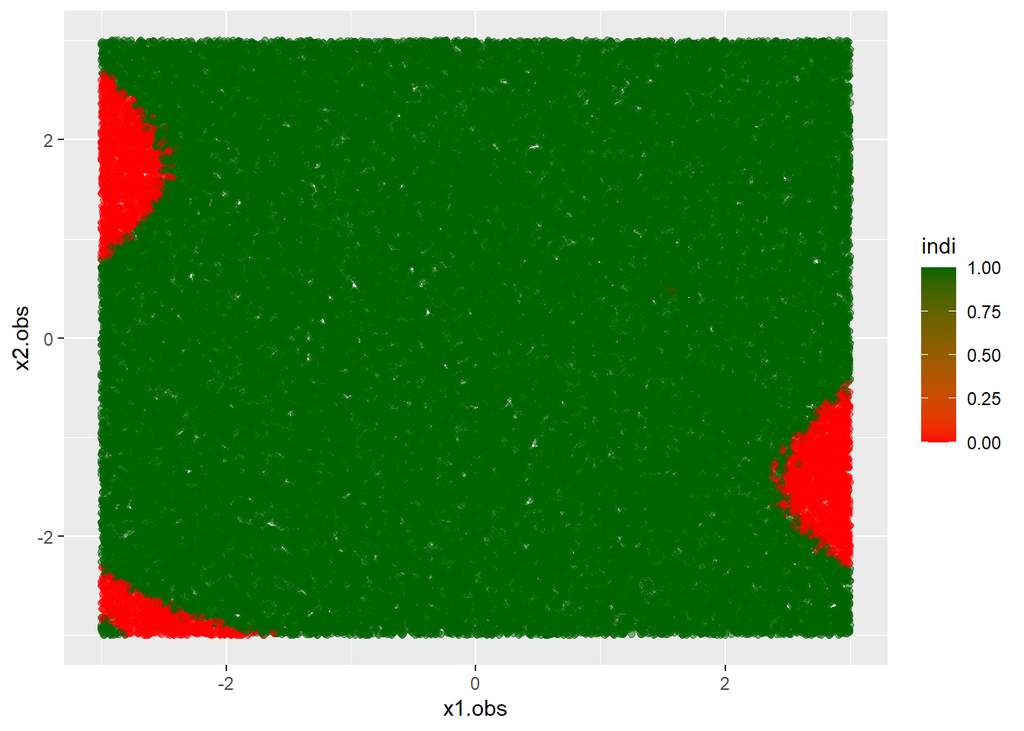

```r
ggplot(data = ic_ml1, aes(x=x1.obs, y=x2.obs, color=indi)) +
  scale_colour_gradient(low = "red", high = "darkgreen") +
  geom_point(alpha=0.5)
```

## 14. Recursos consultados

GOODFELLOW, I.; BENGIO, Y.; COURVILLE, A. Deep learning. Cambridge, Massachusetts: The MIT Press, 2016.

TYCHOBRA, P. ON. How to build your own Neural Network from scratch in R | R-bloggers. , 9. out. 2018. Disponível em: https://www.r-bloggers.com/2018/10/how-to-build-your-own-neural-network-from-scratch-in-r/. Acesso em: 24/8/2021.

VERMA, A. Building A Neural Net from Scratch Using R - Part 1. Disponível em: https://rviews.rstudio.com/2020/07/20/shallow-neural-net-from-scratch-using-r-part-1/. Acesso em: 24/8/2021a.

VERMA, A. Building A Neural Net from Scratch Using R - Part 2. Disponível em: https://rviews.rstudio.com/2020/07/24/building-a-neural-net-from-scratch-using-r-part-2/. Acesso em: 24/8/2021b.